# Tugas Pertemuan 3

Joe Anthonie Oktavian

2026-09-09

### *Packages*

```r
# Mengaktifkan library yang dibutuhkan
#install.packages(c("dLagM", "dynlm", "MLmetrics", "lmtest", "car")) # Run jika belum meng-install

library(dLagM)
library(dynlm)
library(MLmetrics)
library(lmtest)
library(car)
```

### Impor & Pembagian Data

Kita akan menggunakan data simulasi untuk melatih pemodelan. Data dibagi menjadi data Training (untuk membentuk model) dan data Testing (untuk menguji akurasi ramalan).

```r
data_tugas3 <- read.csv("NewDelhi_Air_quality.csv")

# Membagi data (58 observasi pertama untuk training, 14 observasi terakhir untuk testing)
train <- data_tugas3[1:58,]
test <- data_tugas3[59:72,]

# Mengubah format data menjadi objek Time Series (ts)

train.ts <- ts(
  train[, c("AQI", "pm25")],
  frequency = 1
)
```

## 2. Model Koyck

Model Koyck mengatasi masalah infinite distributed lag (pengaruh masa lalu yang tak terhingga) dengan mengasumsikan bahwa semakin jauh jarak lag, semakin kecil pengaruhnya.

Melalui transformasi aljabar, efek masa lalu dari X yang sangat panjang diringkas ke dalam satu variabel saja, yaitu $Y_{t-1}$. Bentuk persamaannya menjadi:

$$Y_t=a(1-\lambda)+\beta_0X_t+\lambda
Y_{t-1}+V_t$$
Catatan: $V_t$ adalah error term gabungan. Pada hasil ringkasan model (estimasi), $V_t$ tidak ditampilkan karena nilai harapannya diasumsikan nol.

### Pemodelan Koyck

Pemodelan ini menggunakan fungsi `koyckDlm()`.

```r
# Membangun Model Koyck
model.koyck <- koyckDlm(x = train$pm25, y = train$AQI)
summary(model.koyck)
```

```
##
## Call:
## "Y ~ (Intercept) + Y.1 + X.t"
##
## Residuals:
##      Min       1Q   Median       3Q      Max
## -2.14443 -0.61319  0.03512  0.48195  2.18725
##
## Coefficients:
##             Estimate Std. Error t value Pr(>|t|)
## (Intercept)   4.0771     1.8299   2.228   0.0301 *
## Y.1           0.8897     0.0588  15.131   <2e-16 ***
## X.t          -0.5723     0.2854  -2.005   0.0500 *
## ---
## Signif. codes:  0 '***' 0.001 '**' 0.01 '*' 0.05 '.' 0.1 ' ' 1
##
## Residual standard error: 0.9279 on 54 degrees of freedom
## Multiple R-Squared: 0.8273,  Adjusted R-squared: 0.8209
## Wald test: 129.1 on 2 and 54 DF,  p-value: < 2.2e-16
##
## Diagnostic tests:
## NULL
##
##                             alpha       beta       phi
## Geometric coefficients:  36.94716 -0.5722988 0.8896496
```

#### Interpretasi Model Koyck

Model Koyck digunakan untuk merepresentasikan pengaruh distributed lag yang bersifat tak hingga dengan asumsi bahwa pengaruh variabel independen menurun secara geometris seiring bertambahnya periode lag. Berdasarkan hasil estimasi, diperoleh parameter peluruhan geometris $\hat{\lambda}=0.88965$.

Dengan $Y_t$ merupakan AQI dan $X_t$ merupakan PM2.5, model Koyck yang diperoleh adalah:

$$AQI_t
=
4.0771
+
0.88965AQI_{t-1}
-
0.57230PM2.5_t
+
V_t$$

Koefisien $AQI_{t-1}$ sebesar 0.88965 menunjukkan adanya persistensi yang cukup kuat pada nilai AQI, sehingga nilai AQI pada periode sebelumnya berhubungan positif dengan nilai AQI pada periode saat ini. Sementara itu, koefisien PM2.5 sebesar -0.57230 menunjukkan bahwa kenaikan PM2.5 pada periode saat ini berasosiasi dengan penurunan AQI sebesar 0.57230 satuan, dengan variabel lain dalam model dianggap tetap.

Parameter $\hat{\lambda}=0.88965$ berada pada rentang $0<\lambda<1$, sehingga asumsi penurunan geometris efek lag terpenuhi. Rata-rata keterlambatan (*mean lag*) dihitung menggunakan:

$$\text{Mean Lag}
=
\frac{\lambda}{1-\lambda}
=
\frac{0.88965}{1-0.88965}
\approx 8.05$$

Karena data memiliki frekuensi hourly, nilai *mean lag* sebesar 8.05 menunjukkan rata-rata keterlambatan efek sekitar 8 jam. Nilai ini merupakan ukuran rata-rata keterlambatan efek dalam model Koyck dan bukan merupakan batas lag maksimum. Model Koyck tetap merepresentasikan efek distributed lag hingga tak terhingga dengan besaran efek yang semakin kecil pada lag yang semakin jauh.

### Peramalan

```r
# Meramalkan 14 periode ke depan
fore.koyck <- forecast(model = model.koyck, x = test$pm25, h = 14)
fore.koyck
```

```
## $forecasts
##  [1] 22.96490 22.79987 22.60639 22.40415 22.24036 22.15991 22.16242 22.20757
##  [9] 22.27123 22.33380 22.39368 22.42982 22.44082 22.47014
##
## $call
## forecast.koyckDlm(model = model.koyck, x = test$pm25, h = 14)
##
## attr(,"class")
## [1] "forecast.koyckDlm" "dLagM"
```

```r
# Cek Akurasi (MAPE) pada data testing
mape.koyck <- MAPE(fore.koyck$forecasts, test$AQI)
cat("MAPE Model Koyck:", mape.koyck, "\n")
```

```
## MAPE Model Koyck: 0.1054825
```

#### Evaluasi Forecasting Model Koyck

Model Koyck digunakan untuk meramalkan AQI sebanyak 14 periode ke depan menggunakan nilai PM2.5 pada data testing. Hasil ramalan menunjukkan nilai AQI berturut-turut sebesar 22.9649, 22.7999, 22.6064, hingga 22.4701. Secara umum, model memprediksi AQI berada pada kisaran 22.16 hingga 22.96 selama periode peramalan. Nilai ramalan mengalami penurunan pada beberapa periode awal, kemudian kembali meningkat secara perlahan pada periode berikutnya.

Evaluasi akurasi dilakukan menggunakan Mean Absolute Percentage Error (MAPE). Hasil perhitungan menghasilkan:

$$MAPE = 0.1054825$$

atau sebesar:

$$MAPE = 10.55\%$$

Nilai tersebut menunjukkan bahwa rata-rata kesalahan absolut relatif hasil peramalan model Koyck terhadap nilai AQI aktual pada data testing adalah sekitar 10.55%. Nilai MAPE yang lebih kecil menunjukkan kemampuan peramalan yang lebih baik, sehingga nilai ini selanjutnya dapat dibandingkan dengan MAPE dari model DLM dan ARDL untuk menentukan model dengan performa forecasting terbaik.

## 3. Regression with Distributed Lag (DLM)

Berbeda dengan Koyck, pemodelan DLM membatasi secara spesifik berapa periode memori masa lalu yang dilibatkan. Batasan ini direpresentasikan dengan parameter $q$.

$$Y_t=\alpha+\beta_0X_t+\beta_1X_{t-1}+…+\beta_qX_{t-q}+e_t$$

### Pemodelan (Lag = 2)

Fungsi yang digunakan adalah `dlm()`. Parameter `q = 2` berarti kita memasukkan $X_t, X_{t-1}$, dan $X_{t-2}$.

```r
model.dlm <- dlm(x = train$pm25, y = train$AQI, q = 2)
summary(model.dlm)
```

```
##
## Call:
## lm(formula = model.formula, data = design)
##
## Residuals:
##     Min      1Q  Median      3Q     Max
## -4.5504 -1.2693 -0.0678  1.0780  4.0378
##
## Coefficients:
##             Estimate Std. Error t value Pr(>|t|)
## (Intercept)   35.453      1.656  21.405  < 2e-16 ***
## x.t           -8.438      2.173  -3.883 0.000293 ***
## x.1            6.515      3.189   2.043 0.046126 *
## x.2           -2.178      1.553  -1.403 0.166651
## ---
## Signif. codes:  0 '***' 0.001 '**' 0.01 '*' 0.05 '.' 0.1 ' ' 1
##
## Residual standard error: 1.84 on 52 degrees of freedom
## Multiple R-squared:  0.343,  Adjusted R-squared:  0.3051
## F-statistic: 9.048 on 3 and 52 DF,  p-value: 6.393e-05
##
## AIC and BIC values for the model:
##        AIC      BIC
## 1 233.0605 243.1873
```

### Penentuan *Lag* Optimum

Untuk menghindari menebak-nebak, kita bisa mencari nilai $q$ terbaik berdasarkan nilai *Akaike Information Criterion (AIC)* terkecil menggunakan fungsi `finiteDLMauto()`.

```r
hasil_dlm <- finiteDLMauto(
  x = train$pm25,
  y = train$AQI,
  q.min = 1,
  q.max = 24,
  model.type = "dlm",
  error.type = "AIC",
  trace = TRUE
)

hasil_dlm
```

```
##    q - k    MASE       AIC       BIC     GMRAE   MBRAE R.Adj.Sq    Ljung-Box
## 24    24 0.23060  38.22792  79.43965  1824.739 0.41960  0.97419 5.334221e-01
## 22    22 0.43270  72.66695 112.25492  6866.070 0.49369  0.94239 9.442900e-01
## 23    23 0.41613  73.05646 113.49551  4635.733 0.47691  0.93647 9.212277e-01
## 21    21 0.62379 101.13913 139.80116 12315.721 0.53126  0.88314 8.941837e-02
## 20    20 0.71573 104.86748 142.53196 22270.083 0.52867  0.87923 4.240095e-03
## 19    19 0.81879 114.48432 151.08268 26331.444 0.52758  0.85361 2.444243e-02
## 18    18 0.96448 124.34984 159.81631 48538.095 2.15479  0.82176 2.967718e-02
## 17    17 1.14851 141.89952 176.17096 43332.336 1.30162  0.73959 9.790011e-03
## 16    16 1.27157 150.48385 183.49957 33163.272 0.92019  0.70005 1.991188e-05
## 15    15 1.30855 150.50678 182.20838 52764.754 2.08990  0.71756 1.354041e-05
## 14    14 1.41703 156.21206 186.54329 66797.318 0.86195  0.69549 3.320913e-05
## 13    13 1.58189 164.15633 193.06293 93708.004 1.07071  0.65508 9.207161e-07
## 12    12 1.61892 171.27270 198.70232 77305.205 0.72643  0.61376 1.588368e-07
## 11    11 1.72537 179.16161 205.06368 73590.588 0.65770  0.56544 3.066269e-08
## 10    10 1.72201 186.26532 210.59093 49688.218 0.71611  0.52879 1.423614e-08
## 9      9 1.85325 195.59795 218.29979 44081.168 0.73051  0.47894 5.052925e-09
## 8      8 1.88799 199.12048 220.15273 38823.623 0.66594  0.50264 2.075788e-10
## 7      7 1.84754 200.06548 219.38374 30520.822 0.62313  0.53206 5.330174e-10
## 6      6 1.73867 201.10512 218.66631 22650.853 0.56392  0.54223 4.524737e-10
## 5      5 1.75280 204.08125 219.84358 23085.145 1.65593  0.53463 6.980942e-10
## 4      4 1.85610 209.93137 223.85426 31881.258 0.72405  0.50086 2.767593e-09
## 3      3 2.13163 220.31674 232.36074 38604.333 0.77447  0.42645 1.445641e-09
## 2      2 2.18873 233.06050 243.18725 29920.773 0.56412  0.30506 1.907737e-06
## 1      1 2.28775 246.71988 254.89209 24669.648 0.75741  0.15281 5.737415e-09
```

```r
# Membangun ulang DLM dengan Lag Optimum (q=24)
model.dlm.opt <- dlm(x = train$pm25, y = train$AQI, q = 24)
summary(model.dlm.opt)
```

```
##
## Call:
## lm(formula = model.formula, data = design)
##
## Residuals:
##      Min       1Q   Median       3Q      Max
## -0.46609 -0.11423 -0.01453  0.13549  0.35229
##
## Coefficients:
##             Estimate Std. Error t value Pr(>|t|)
## (Intercept)  29.2850     3.1320   9.350  1.4e-05 ***
## x.t         -17.8409     3.9445  -4.523  0.00194 **
## x.1          24.0189    11.5161   2.086  0.07049 .
## x.2         -24.5685    16.5782  -1.482  0.17663
## x.3          21.7188    16.9487   1.281  0.23593
## x.4         -13.4371    13.4366  -1.000  0.34658
## x.5           2.2909    12.6190   0.182  0.86045
## x.6           9.7406    16.7658   0.581  0.57725
## x.7         -13.7704    18.2161  -0.756  0.47135
## x.8           7.9673    15.7761   0.505  0.62716
## x.9          -0.7919    15.3481  -0.052  0.96012
## x.10          6.6389    15.4348   0.430  0.67846
## x.11         -5.7535    15.1495  -0.380  0.71399
## x.12          0.5126    18.3675   0.028  0.97842
## x.13          1.0843    20.2647   0.054  0.95864
## x.14         -4.7430    16.6486  -0.285  0.78296
## x.15          6.1569    11.4379   0.538  0.60503
## x.16        -19.2629     9.3911  -2.051  0.07437 .
## x.17         25.8830     8.0981   3.196  0.01268 *
## x.18        -24.2041     7.3070  -3.312  0.01066 *
## x.19         24.9336     6.9652   3.580  0.00719 **
## x.20        -15.5780     6.0294  -2.584  0.03243 *
## x.21          7.1946     4.0776   1.764  0.11566
## x.22          3.1595     2.6163   1.208  0.26169
## x.23         -5.6765     2.2281  -2.548  0.03430 *
## x.24          3.8268     1.0101   3.789  0.00532 **
## ---
## Signif. codes:  0 '***' 0.001 '**' 0.01 '*' 0.05 '.' 0.1 ' ' 1
##
## Residual standard error: 0.3956 on 8 degrees of freedom
## Multiple R-squared:  0.9937, Adjusted R-squared:  0.9742
## F-statistic: 50.81 on 25 and 8 DF,  p-value: 2.288e-06
##
## AIC and BIC values for the model:
##        AIC      BIC
## 1 38.22792 79.43965
```

### Peramalan dengan Lag Optimum

```r
fore.dlm.opt <- forecast(
  model = model.dlm.opt,
  x = test$pm25,
  h = 14
)

mape.dlm.opt <- MAPE(
  fore.dlm.opt$forecasts,
  test$AQI
)

cat("MAPE Model DLM Optimum:", mape.dlm.opt, "\n")
```

```
## MAPE Model DLM Optimum: 0.1597327
```

Berdasarkan hasil evaluasi, model DLM optimum menghasilkan nilai MAPE sebesar 0.1597 atau 15.97%. Nilai tersebut menunjukkan bahwa rata-rata kesalahan absolut relatif hasil peramalan AQI terhadap nilai aktual pada data testing adalah sekitar 15.97%.

## 4. Autoregressive Distributed Lag (ARDL)

Model ARDL menggabungkan pengaruh dari peubah independen masa lalu dan peubah dependen masa lalu.

Pada *package* `dLagM` (khusus fungsi `ardlDlm`), aturannya adalah:

- $p$ = panjang *lag* peubah independen ($X$).
- $q$ = panjang *lag* peubah dependen ($Y$).

### Pemodelan

```r
# Model ARDL dengan lag X = 1 dan lag Y = 1
model.ardl <- ardlDlm(formula = AQI ~ pm25, data = train, p = 1, q = 1)
summary(model.ardl)
```

```
##
## Time series regression with "ts" data:
## Start = 2, End = 58
##
## Call:
## dynlm(formula = as.formula(model.text), data = data)
##
## Residuals:
##      Min       1Q   Median       3Q      Max
## -2.14374 -0.61593  0.03152  0.47781  2.18777
##
## Coefficients:
##             Estimate Std. Error t value Pr(>|t|)
## (Intercept)  4.00535    2.07382   1.931   0.0588 .
## pm25.t      -0.52588    0.80265  -0.655   0.5152
## pm25.1      -0.03046    0.55965  -0.054   0.9568
## AQI.1        0.89112    0.06338  14.060   <2e-16 ***
## ---
## Signif. codes:  0 '***' 0.001 '**' 0.01 '*' 0.05 '.' 0.1 ' ' 1
##
## Residual standard error: 0.9366 on 53 degrees of freedom
## Multiple R-squared:  0.8273, Adjusted R-squared:  0.8175
## F-statistic: 84.63 on 3 and 53 DF,  p-value: < 2.2e-16
```

### Peramalan dengan ARDL (1,1)

```r
fore.ardl <- forecast(
  model = model.ardl,
  x = test$pm25,
  h = 14
)

mape.ardl <- MAPE(
  fore.ardl$forecasts,
  test$AQI
)

cat(
  "MAPE Model ARDL (1,1):",
  round(mape.ardl * 100, 2),
  "%\n"
)
```

```
## MAPE Model ARDL (1,1): 10.64 %
```

#### *Lag* Optimum Model

```r
# Menentukan kombinasi lag optimum berdasarkan AIC
hasil_ardl <- data.frame(
  p = integer(),
  q = integer(),
  AIC = numeric()
)

# Mencoba kombinasi lag p dan q
for (p in 1:10) {
  for (q in 1:10) {

    model <- tryCatch(
      ardlDlm(
        formula = AQI ~ pm25,
        data = train,
        p = p,
        q = q
      ),
      error = function(e) NULL
    )

    if (!is.null(model)) {
      hasil_ardl <- rbind(
        hasil_ardl,
        data.frame(
          p = p,
          q = q,
          AIC = AIC(model$model)
        )
      )
    }
  }
}

# Mengurutkan berdasarkan AIC terkecil
hasil_ardl <- hasil_ardl[order(hasil_ardl$AIC), ]

# Menampilkan 10 kombinasi terbaik
head(hasil_ardl, 10)
```

```
##      p  q       AIC
## 99  10  9  87.92520
## 100 10 10  88.82647
## 96  10  6  89.28267
## 98  10  8  90.76779
## 97  10  7  91.21723
## 95  10  5  95.62728
## 90   9 10  98.65316
## 86   9  6  98.89382
## 94  10  4  99.27369
## 87   9  7 100.80581
```

```r
# Menentukan kombinasi lag optimum
p_opt <- hasil_ardl$p[1]
q_opt <- hasil_ardl$q[1]

hasil_lag_ardl <- data.frame(
  Lag_Y_opt = p_opt,
  Lag_X_opt = q_opt,
  AIC = hasil_ardl$AIC[1]
)

hasil_lag_ardl
```

```
##   Lag_Y_opt Lag_X_opt     AIC
## 1        10         9 87.9252
```

### Peramalan dengan Lag Optimum

```r
# Membentuk model ARDL optimum
model.ardl.optimal <- ardlDlm(
  formula = AQI ~ pm25,
  data = train,
  p = p_opt,
  q = q_opt
)

# Forecast 14 periode data testing
fore.ardl.optimal <- forecast(
  model = model.ardl.optimal,
  x = test$pm25,
  h = 14
)

# Menghitung MAPE
mape.ardl.optimal <- MAPE(
  fore.ardl.optimal$forecasts,
  test$AQI
)

cat(
  "MAPE Model ARDL Optimum:",
  round(mape.ardl.optimal * 100, 2),
  "%\n"
)
```

```
## MAPE Model ARDL Optimum: 20.31 %
```

## 5. Pendekatan dengan Library `dynlm` dan Uji Asumsi

Pemodelan juga dapat dilakukan secara manual menggunakan library `dynlm`. Keunggulannya adalah kemudahan dalam memanggil fungsi uji asumsi sisaan (karena format outputnya setara dengan regresi linier standar `lm`).

Gunakan fungsi `L()` untuk memanggil nilai masa lalu (*lag*).

```r
# Sama dengan DLM (q=1)
cons_lm1 <- dynlm(
  AQI ~ pm25 + L(pm25),
  data = train.ts
)

# Setara dengan Model Autoregressive Murni
# (melibatkan pm25 dan lag AQI)
cons_lm2 <- dynlm(
  AQI ~ pm25 + L(AQI),
  data = train.ts
)

# Sama dengan ARDL (p=1, q=1)
cons_lm3 <- dynlm(
  AQI ~ pm25 + L(pm25) + L(AQI),
  data = train.ts
)
```

### Uji Asumsi Model (cons_lm1)

#### 1. Uji Autokorelasi (Durbin-Watson)

H0: Tidak ada autokorelasi

```r
dwtest(cons_lm1)
```

```
##
##  Durbin-Watson test
##
## data:  cons_lm1
## DW = 0.3953, p-value = 1.217e-15
## alternative hypothesis: true autocorrelation is greater than 0
```

#### 2. Uji Heteroskedastisitas (Breusch-Pagan)

H0: Ragam sisaan homogen

```r
bptest(cons_lm1)
```

```
##
##  studentized Breusch-Pagan test
##
## data:  cons_lm1
## BP = 10.715, df = 2, p-value = 0.004712
```

#### 3. Uji Normalitas (Shapiro-Wilk)

H0: Sisaan berdistribusi normal

```r
shapiro.test(residuals(cons_lm1))
```

```
##
##  Shapiro-Wilk normality test
##
## data:  residuals(cons_lm1)
## W = 0.9602, p-value = 0.05818
```

### Uji Asumsi Model (cons_lm2)

#### 1. Uji Autokorelasi (Durbin-Watson)

H0: Tidak ada autokorelasi

```r
dwtest(cons_lm2)
```

```
##
##  Durbin-Watson test
##
## data:  cons_lm2
## DW = 1.0689, p-value = 3.466e-05
## alternative hypothesis: true autocorrelation is greater than 0
```

#### 2. Uji Heteroskedastisitas (Breusch-Pagan)

H0: Ragam sisaan homogen

```r
bptest(cons_lm2)
```

```
##
##  studentized Breusch-Pagan test
##
## data:  cons_lm2
## BP = 0.62294, df = 2, p-value = 0.7324
```

#### 3. Uji Normalitas (Shapiro-Wilk)

H0: Sisaan berdistribusi normal

```r
shapiro.test(residuals(cons_lm2))
```

```
##
##  Shapiro-Wilk normality test
##
## data:  residuals(cons_lm2)
## W = 0.97999, p-value = 0.4631
```

### Uji Asumsi Model (cons_lm3)

#### 1. Uji Autokorelasi (Durbin-Watson)

H0: Tidak ada autokorelasi

```r
dwtest(cons_lm3)
```

```
##
##  Durbin-Watson test
##
## data:  cons_lm3
## DW = 1.0666, p-value = 2.263e-05
## alternative hypothesis: true autocorrelation is greater than 0
```

#### 2. Uji Heteroskedastisitas (Breusch-Pagan)

H0: Ragam sisaan homogen

```r
bptest(cons_lm3)
```

```
##
##  studentized Breusch-Pagan test
##
## data:  cons_lm3
## BP = 0.63463, df = 3, p-value = 0.8885
```

#### 3. Uji Normalitas (Shapiro-Wilk)

H0: Sisaan berdistribusi normal

```r
shapiro.test(residuals(cons_lm3))
```

```
##
##  Shapiro-Wilk normality test
##
## data:  residuals(cons_lm3)
## W = 0.97953, p-value = 0.4439
```

Interpretasi: Pada `cons_lm1`, uji Durbin-Watson menghasilkan DW = 0.3953 dengan p-value = 1.217 × 10⁻¹⁵, sehingga terdapat autokorelasi positif pada sisaan. Uji Breusch-Pagan menghasilkan p-value = 0.004712, yang menunjukkan adanya heteroskedastisitas. Sementara itu, uji Shapiro-Wilk menghasilkan p-value = 0.05818, sehingga tidak terdapat bukti penyimpangan normalitas sisaan.

Pada `cons_lm2`, uji Durbin-Watson menghasilkan DW = 1.0689 dengan p-value = 3.466 × 10⁻⁵, sehingga terdapat autokorelasi positif pada sisaan. Uji Breusch-Pagan (p-value = 0.7324) dan Shapiro-Wilk (p-value = 0.4631) menunjukkan tidak terdapat bukti heteroskedastisitas maupun penyimpangan normalitas sisaan.

Pada `cons_lm3`, diperoleh DW = 1.0666 dengan p-value = 2.263 × 10⁻⁵, sehingga masih terdapat autokorelasi positif pada sisaan. Namun, uji Breusch-Pagan (p-value = 0.8885) dan Shapiro-Wilk (p-value = 0.4439) menunjukkan tidak terdapat bukti heteroskedastisitas maupun penyimpangan normalitas sisaan.

## 6. Perbandingan Performa MOdel

### MAPE

```r
# Ringkasan Akurasi
akurasi <- matrix(
  c(
    mape.koyck,
    mape.dlm.opt,
    mape.ardl,
    mape.ardl.optimal
  )
)

row.names(akurasi) <- c(
  "Koyck",
  "DLM Optimum",
  "ARDL (1,1)",
  "ARDL Optimum (10,9)"
)

colnames(akurasi) <- c("MAPE")

print(akurasi)
```

```
##                          MAPE
## Koyck               0.1054825
## DLM Optimum         0.1597327
## ARDL (1,1)          0.1064417
## ARDL Optimum (10,9) 0.2031186
```

### Deviance

```r
# Perbandingan Deviance
deviance_model <- data.frame(
  Model = c("DLM (q=1)",
            "Model dengan Lag Y",
            "ARDL (1,1)"),
  Deviance = c(
    deviance(cons_lm1),
    deviance(cons_lm2),
    deviance(cons_lm3)
  )
)

deviance_model
```

```
##                Model  Deviance
## 1          DLM (q=1) 219.91526
## 2 Model dengan Lag Y  46.49499
## 3         ARDL (1,1)  46.49239
```

Interpretasi: Berdasarkan nilai deviance, model DLM (q=1) menghasilkan deviance sebesar 219,9153, sedangkan model dengan lag Y dan ARDL (1,1) masing-masing menghasilkan deviance sebesar 46,4950 dan 46,4924. Dengan demikian, model ARDL (1,1) memiliki deviance paling kecil sehingga memberikan kecocokan terhadap data training yang paling baik, meskipun perbedaannya dengan model dengan lag Y sangat kecil.

### Visualisasi

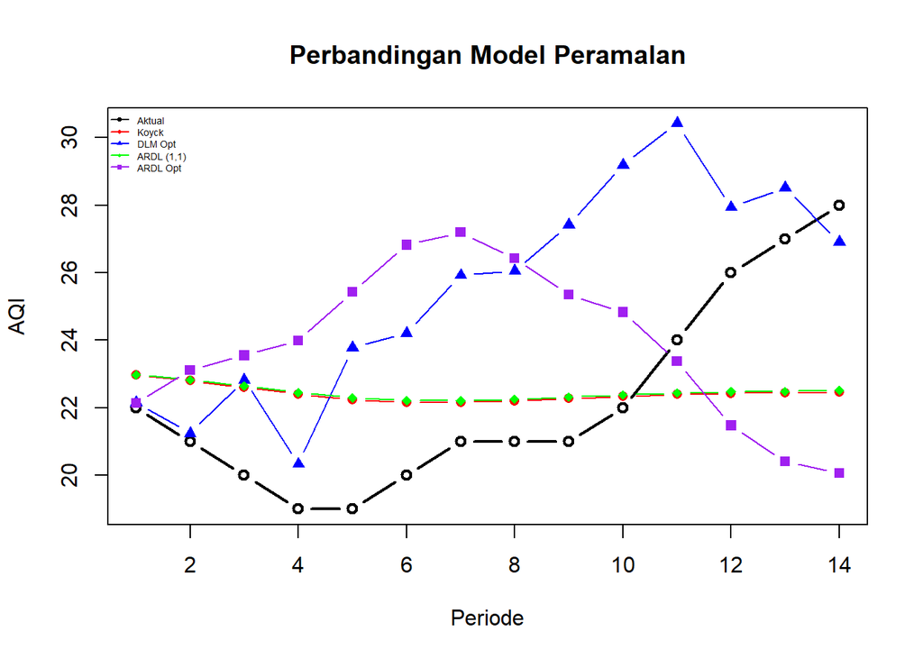

```r
# Visualisasi Perbandingan Model Peramalan
par(mfrow = c(1,1))

plot(
  1:14, test$AQI,
  type = "b",
  col = "black",
  lwd = 2,
  ylim = range(c(
    test$AQI,
    fore.koyck$forecasts,
    fore.dlm.opt$forecasts,
    fore.ardl$forecasts,
    fore.ardl.optimal$forecasts
  )),
  ylab = "AQI",
  xlab = "Periode",
  main = "Perbandingan Model Peramalan"
)

lines(1:14, fore.koyck$forecasts, type = "b", col = "red", pch = 16)
lines(1:14, fore.dlm.opt$forecasts, type = "b", col = "blue", pch = 17)
lines(1:14, fore.ardl$forecasts, type = "b", col = "green", pch = 18)
lines(1:14, fore.ardl.optimal$forecasts, type = "b", col = "purple", pch = 15)

legend(
  "topleft",
  legend = c("Aktual", "Koyck", "DLM Opt", "ARDL (1,1)", "ARDL Opt"),
  col = c("black", "red", "blue", "green", "purple"),
  lty = 1,
  pch = c(1, 16, 17, 18, 15),
  bty = "n",
  cex = 0.45
)
```